# NFL Players 2016 Data

STT2860 Project 01 Spring 2023

Monday, March 06, 2023 @ 02:29 PM

### Packages Used

```r
library(tidyverse)
library(ggthemes)
```

### NFL Players 2016 Dataset

You can read description of the dataset [HERE](https://stat-jet-asu.github.io/Datasets/InstructorDescriptions/NFLplayers2016.html).

```r
dataURL <- "https://raw.githubusercontent.com/STAT-JET-ASU/Datasets/master/Instructor/NFLplayers2016.csv"

nfldata <- read_csv(dataURL) %>%
  mutate(Playtime = factor(Playtime, levels = c("Rookie", "1-4 Yrs", "5-8 Yrs", "9-12 Yrs", "13+ Yrs")))
```

Use `glimpse()` to explore the structure of the `nfldata` dataset.

```r
glimpse(nfldata)
```

```
Rows: 2,764
Columns: 12
$ Jersey      <dbl> 53, 77, 65, 28, 1, 35, 43, 25, 46, 39, NA, 21, NA, 21, NA,…
$ Name        <chr> "A.Q. Shipley", "Evan Boehm", "Taylor Boggs", "Justin Beth…
$ Position    <chr> "C", "C", "C", "CB", "CB", "CB", "CB", "CB", "CB", "CB", "…
$ Age         <dbl> 30, 22, 29, 26, 22, 25, 31, 29, 26, 26, 24, 23, NA, 26, NA…
$ Height      <dbl> 73, 74, 75, 72, 72, 69, 70, 70, 70, 70, 70, 71, 73, 73, 74…
$ Weight      <dbl> 307, 309, 302, 200, 182, 200, 197, 187, 183, 190, 174, 197…
$ Years       <dbl> 5, 0, 4, 5, 0, 2, 9, 8, 4, 4, 0, 0, 0, 6, 0, 5, 0, 11, 7, …
$ College     <chr> "Penn State", "Missouri", "Humboldt State", "Presbyterian …
$ Team        <chr> "Arizona", "Arizona", "Arizona", "Arizona", "Arizona", "Ar…
$ PositionGrp <chr> "Offensive Line", "Offensive Line", "Offensive Line", "Def…
$ Side        <chr> "Offense", "Offense", "Offense", "Defense", "Defense", "De…
$ Playtime    <fct> 5-8 Yrs, Rookie, 1-4 Yrs, 5-8 Yrs, Rookie, 1-4 Yrs, 9-12 Y…
```

Use `head()` to explore the structure of the `nfldata` dataset.

```r
head(nfldata)
```

```
# A tibble: 6 × 12
  Jersey Name      Posit…¹   Age Height Weight Years College Team  Posit…² Side
   <dbl> <chr>     <chr>   <dbl>  <dbl>  <dbl> <dbl> <chr>   <chr> <chr>   <chr>
1     53 A.Q. Shi… C          30     73    307     5 Penn S… Ariz… Offens… Offe…
2     77 Evan Boe… C          22     74    309     0 Missou… Ariz… Offens… Offe…
3     65 Taylor B… C          29     75    302     4 Humbol… Ariz… Offens… Offe…
4     28 Justin B… CB         26     72    200     5 Presby… Ariz… Defens… Defe…
5      1 Harlan M… CB         22     72    182     0 Southe… Ariz… Defens… Defe…
6     35 Cariel B… CB         25     69    200     2 Adams … Ariz… Defens… Defe…
# … with 1 more variable: Playtime <fct>, and abbreviated variable names
#   ¹Position, ²PositionGrp
```

### Plot #1: Bar Plot of Playtime

- Create a bar plot for the variable `Playtime`.
- Change the bar colors from gray to some other color/colors.
- Modify the x-axis so that `Yrs` is not abbreviated in the labels.
- Scale the y-axis so it has tick marks every 100 units (e.g., 100, 200, etc.).
- Add an informative title and appropriate labels for both axes.
- You may optionally add a subtitle or caption for more clarity.
- Add the built-in `theme_light()` from ggplot2 to your plot.
- Your final plot should *not* have a legend on it.

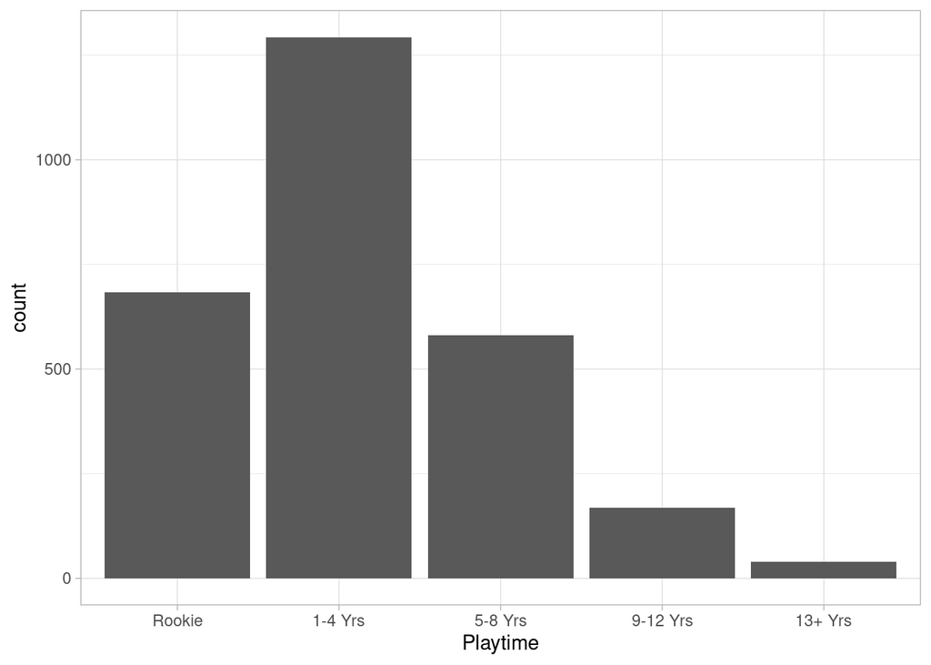

```r
ggplot(nfldata, aes(x = Playtime)) +
  geom_bar() +
  theme_light()
```

```r
# theme(panel.background = element_rect(fill = "white"))
```

Do you think most NFL players should look forward to long careers, based on your plot?

### Plot #2: Histogram of Weight

- Create a histogram with 25 bins for the variable `Weight`.
- Use `fill =` to include information from the variable `Side`.
- Add formatting in the geometry so the bars are outlined in black.
- Use `scale_fill_manual()` to change the colors used in the bars.
- Add the built-in `theme_minimal()` from ggplot2 to your histogram.
- Use `theme()` to move the legend to the bottom and remove its title.
- Add an informative title and appropriate labels for both axes.
- You may optionally add a subtitle or caption for more clarity.
- Be sure to include any units of measure in the axis labels.

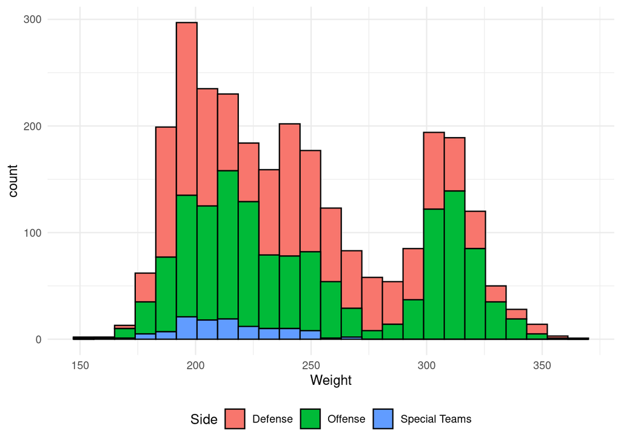

```r
ggplot(nfldata, aes(x = Weight, fill = Side)) +
  geom_histogram(bins = 25, color = "black") +
  theme_minimal() +
  theme(legend.position="bottom")
```

Discuss two group comparisons and/or interesting features of this plot.

### Plot #3: Density Plot of BMI

Body mass index (BMI) is a measure of body fat based on height and weight. The formula for calculating BMI is BMI = kg/m<sup>2</sup> where kg is weight in kilograms and m<sup>2</sup> is height in meters squared. The “healthy” range for BMI is 18.5 to 24.9; BMI > 25 is “overweight”; 30-39 is “obese”; and 40+ “morbidly obese”.

- Use `mutate()` to compute BMI for the football players.
- Save the dataset containing the new variable as `nfldataBMI`.

```r
nfldataBMI <- nfldata %>%
  mutate(BMI = (0.4536 * Weight) / (0.0254 * Height)^2)
```

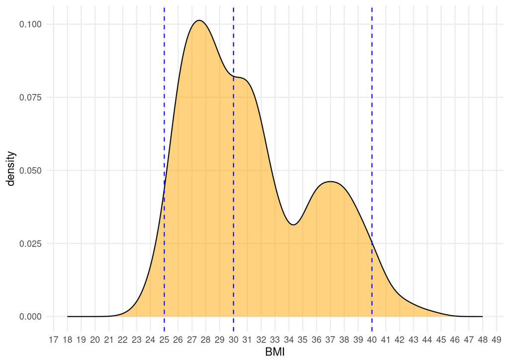

```r
ggplot(nfldataBMI, aes(x = BMI)) +
  geom_density(bw = 0.75, fill = "orange", alpha = 0.5) +
  geom_vline(xintercept = c(25, 30, 40), color = "blue", linetype = "dashed") +
  scale_x_continuous(breaks = 1:50, limits = c(18, 48)) +
  theme_minimal() +
  theme(panel.grid.minor = element_blank())
```

Many people suggest that BMI is a poor measure for athletes, who often have a high body weight due to muscle mass versus fat. What does your plot suggest about this?

### Plot 4: Violin and Box Plots of Age

- We want to compare `Age` among the three `Side` groups.
- Use `geom_violin()` as the first geometry layer of the plot.
- Add `geom_boxplot()` as the second geometry layer of the plot.
- Adjust the width of the boxplots so they are completely inside the violins.
- Fill the boxplots with a color to visually contrast with the violins.
- Increase the size of the boxplot outliers for enhanced visibility.
- Add an informative title and appropriate labels for both axes.
- You may optionally add a subtitle or caption for more clarity.
- Be sure to include any units of measure in the axis labels.
- Add any other formatting you feel will enhance meaning.

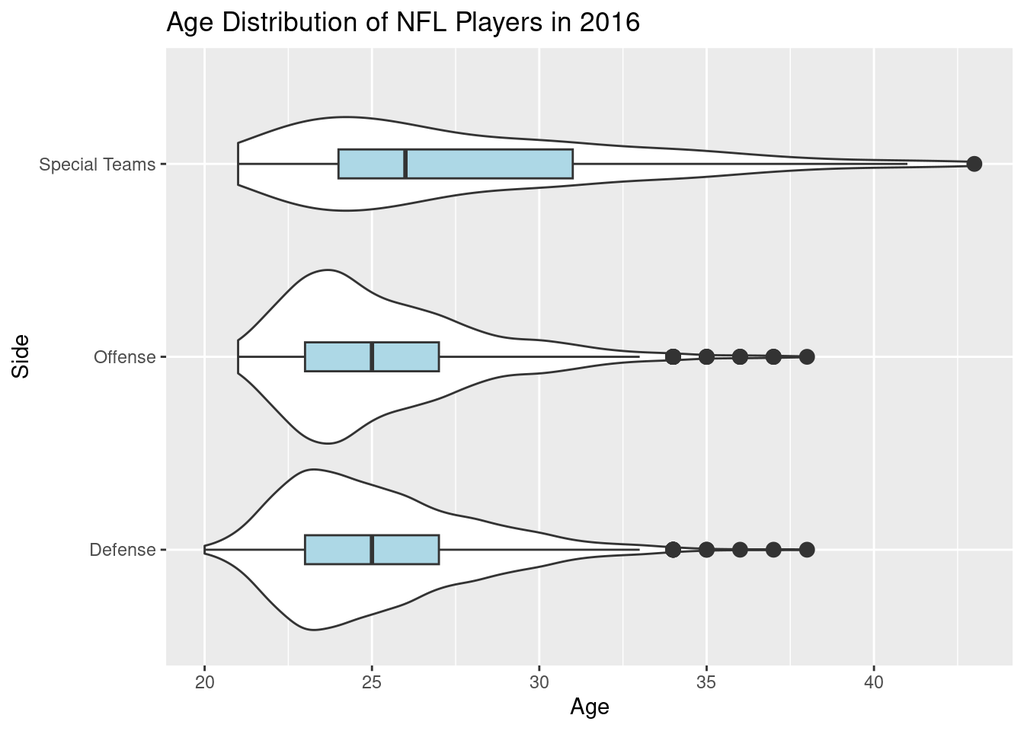

```r
ggplot(nfldata, aes(x = Age, y = Side)) +
  geom_violin() +
  geom_boxplot(width = 0.15, fill = "lightblue", outlier.size = 3) +
  ggtitle("Age Distribution of NFL Players in 2016")
```

Discuss two group comparisons and/or interesting features of this plot.

#### Offensive Players

- Use `Side` to `filter()` the dataset to choose `Offense` players only.
- Save this new dataset containing the offensive players as `offdata`.
- Create a scatterplot of player weight (y) versus player height (x).
- Use the `color =` aesthetic to add information from `PositionGrp`.
- Add an appropriate title and better labels for the x and y axes.
- Be sure to include any units of measure in the axis labels.

#### Defensive Players

- Use `Side` to `filter()` the dataset to choose `Defense` players only.
- Save this new dataset containing the defensive players as `defdata`.
- Create a scatterplot of player weight (y) versus player height (x).
- Use the `color =` aesthetic to add information from `PositionGrp`.
- Add an appropriate title and better labels for the x and y axes.
- Be sure to include any units of measure in the axis labels.

### Plot 6: Your Choice!

Create one more plot of your choice using the `nfldata`. Explain what you were hoping or intending to explore with your plot.